# NetworkDataCompanion Quickstart Guide

# About NetworkDataCompanion

The `NetworkDataCompanion` R package is a collection of utilities for wrangling TCGA data. While it was developed to serve as the engine behind `tcga-data-nf`, the Nextflow workflow presented in Fanfani et al. (2024), `NetworkDataCompanion` is a stand-alone package that can be used independently. The primary goal of the package is to provide version-controlled and unit-tested functions for common tasks involved in network analyses of TCGA data, such as calculating gene-level summary measures of methylation data, normalizing RNA-seq data, and integrating multiple omics by mapping various file identifiers back to TCGA barcodes.

While none of these tasks are particularly complex, `NetworkDataCompanion` is motivated by their ubiquity. Beyond its role in `tcga-data-nf`, this package aims to:

1. Reduce “re-work” by eliminating the need for everyone to write a few lines of code to, e.g., map TCGA identifiers in their own scripts
2. Reduce the error-prone nature of the type of coding described in (1) by offering a centralized, maintained, version-controlled, and unit-tested resource for general use.

# Preparing the workspace

The first step is to install `NetworkDataCompanion` from GitHub using the `devtools` library and the `install_github` function. Here, we have suppressed messages as there are quite a few.

```r
library(devtools)
devtools::install_github("QuackenbushLab/NetworkDataCompanion")
```

Once you have installed the package, load the library into your workspace.

```r
library(NetworkDataCompanion)
```

# Download demonstration data

Once you have installed the package, you next need to download the data used in this quickstart.

These data are from the TCGA COAD analysis presented in Fanfani et al. (2024) and can be downloaded from the Harvard Dataverse here: https://doi.org/10.7910/DVN/MCSSYJ

For the script below to work, please place the `tcga-data-supplement` directory in the same working directory as this RMarkdown. Alternatively, you can modify the `datapath` variable below.

For reference on the source of the data, the full workflow of the COAD analysis is available at https://github.com/QuackenbushLab/tcga-data-supplement/.

Data acknowledgement: These data were generated by the TCGA Research Network: https://www.cancer.gov/tcga.

# Working with the NetworkDataCompanion Object

The most simple way to get started with `NetworkDataCompanion` is to create an object using the `CreateNetworkDataCompanionObject` function with an empty argument. Here, we call the object `ndc`:

```r
ndc = NetworkDataCompanion::CreateNetworkDataCompanionObject()
```

There are a few built-in attributes that will be accessible to the functions of the Companion:

```r
ls(ndc)
```

```
## [1] "clinical_patient_data" "gene_mapping"          "project_name"
## [4] "sample_type_mapping"   "TCGA_purities"
```

Of these, `gene_mapping` and `sample_type_mapping` are loaded with the empty constructor. For the other attributes, we must supply a patient data file and TCGA cancer type. For the COAD example, we can use the following:

```r
datapath = "tcga-data-supplement/data/processed/batch-coad-subtype-20240510/tcga_coad_cms1/"
patient_data = paste0(datapath,"data_download/clinical/clinical_patient_coad.csv")
```

We input these to the constructor to load the relevant data into the Companion object:

```r
ndc = NetworkDataCompanion::CreateNetworkDataCompanionObject(clinical_patient_file = patient_data,project_name = "COAD")
```

Now, we can see the other attributes. The project name helps us keep track of which cancer we are working with:

```r
ndc$project_name
```

```
## [1] "COAD"
```

The clinical patient data stores TCGA barcodes and a range of other patient-level information:

```r
ndc$clinical_patient_data[1:5,1:5]
```

```
##                       bcr_patient_uuid bcr_patient_barcode form_completion_date
## 3 A94E1279-A975-480A-93E9-7B1FF05CBCBF        TCGA-3L-AA1B            2014-4-22
## 4 92554413-9EBC-4354-8E1B-9682F3A031D9        TCGA-4N-A93T            2014-10-1
## 5 A5E14ADD-1552-4606-9FFE-3A03BCF76640        TCGA-4T-AA8H             2014-6-5
## 6 1136DD50-242A-4659-AAD4-C53F9E759BB3        TCGA-5M-AAT4            2015-1-27
## 7 CE00896A-F7D2-4123-BB95-24CB6E53FC32        TCGA-5M-AAT6            2015-1-27
##            histologic_diagnosis prospective_collection
## 3          Colon Adenocarcinoma                    YES
## 4          Colon Adenocarcinoma                    YES
## 5 Colon Mucinous Adenocarcinoma                     NO
## 6          Colon Adenocarcinoma                     NO
## 7          Colon Adenocarcinoma                     NO
```

The `TCGA_purities` attribute contains the information about tumor purity for each sample. Because these TCGA data are from bulk tissue, there may be some non-tumor cells in the each sample as well. Higher purity samples will give more accurate depiction of the tumor microenvironment and the user may wish to filter based on purity.

```r
head(ndc$TCGA_purities)
```

```
##                  Cancer_type ESTIMATE ABSOLUTE   LUMP  IHC    CPE
## TCGA-3L-AA1B-01A        COAD   0.9025       NA 0.6238 0.70 0.7913
## TCGA-4N-A93T-01A        COAD   0.9752       NA 0.7915 0.75 0.7898
## TCGA-4T-AA8H-01A        COAD   0.9865       NA     NA 0.60 0.8917
## TCGA-5M-AAT4-01A        COAD   0.9720       NA     NA 0.70 0.8372
## TCGA-5M-AAT5-01A        COAD   0.9752       NA     NA 0.75 0.8170
## TCGA-5M-AAT6-01A        COAD   0.7275       NA     NA 0.80 0.6712
```

# NetworkDataCompanion Functions

The `tcga-data-nf` workflow retrieves five different data types: clinical data, expression, mutations, copy number variation (CNV) data, and methylation. The clinical data is used in the Companion object constructor. The other data types can be wrangled with the Companion member functions.

First, we define paths to the data:

```r
exp_datapath = paste0(datapath,"data_download/recount3/tcga_coad_cms1.rds")
mut_datapath = paste0(datapath,"data_download/mutations/tcga_coad_cms1_mutations.txt")
mut_pivot_datapath = paste0(datapath, "data_download/mutations/tcga_coad_cms1_mutations_pivot.csv")
cnv_datapath = paste0(datapath, "data_download/cnv/tcga_coad_cms1.csv")
meth_datapath = paste0(datapath, "data_download/methylation/tcga_coad_cms1_methylations.txt")
```

## Functions for working with expression

First, we read in the expression data, which is downloaded as both an .rds file and as a .csv file in the Download phase of the `tcga-data-nf` pipeline. The .rds file contains the `RangedSummarizedExperiment` object, so this is the downloaded file that we work with here. The .csv file is provided for convenience if you have other applications that do not require the `RangedSummarizedExperiment`.

```r
expr_data = readRDS(exp_datapath)
expr_data
```

```
## class: RangedSummarizedExperiment
## dim: 63856 80
## metadata(8): time_created recount3_version ... annotation recount3_url
## assays(1): raw_counts
## rownames(63856): ENSG00000278704.1 ENSG00000277400.1 ...
##   ENSG00000182484.15_PAR_Y ENSG00000227159.8_PAR_Y
## rowData names(10): source type ... havana_gene tag
## colnames(80): 196281bd-2c05-46d3-a53c-ead8639ef02d
##   45cedf59-bc7a-4d86-8c2d-9a91ac141d30 ...
##   bcd07f56-fa83-473f-b5d1-9c637299c7e2
##   b444dc9f-6f2c-4cbc-9e1c-7b9e0fc790f2
## colData names(937): rail_id external_id ... recount_seq_qc.errq
##   BigWigURL
```

To extract metadata from the `RangedSummarizedExperiment`, we use the `extractSampleAndGeneInfo` method. This produces two dataframes: `rds_gene_info`, which stores gene identifiers and other gene-level metadata, and `rds_sample_info`, which stores sample identifiers such as TCGA barcodes, patient characteristics, and sample characteristics.

```r
expr_metadata = ndc$extractSampleAndGeneInfo(expr_data)
ls(expr_metadata)
```

```
## [1] "rds_gene_info"   "rds_sample_info"
```

For example, if we wish to get the gene names and Ensembl IDs for the first five genes in the dataset, we can use:

```r
expr_metadata$rds_gene_info %>%
  dplyr::select(gene_id,gene_name) %>%
  slice_head(n=5)
```

```
##             gene_id  gene_name
## 1 ENSG00000278704.1 BX004987.1
## 2 ENSG00000277400.1 AC145212.2
## 3 ENSG00000274847.1 AC145212.1
## 4 ENSG00000277428.1      Y_RNA
## 5 ENSG00000276256.1 AC011043.1
```

Similarly, let’s get the TCGA barcode and vital status of the patients who provided the first 5 samples:

```r
expr_metadata$rds_sample_info %>%
  dplyr::select(tcga.tcga_barcode,tcga.gdc_cases.diagnoses.vital_status) %>%
  slice_head(n=5)
```

```
##                                                 tcga.tcga_barcode
## 196281bd-2c05-46d3-a53c-ead8639ef02d TCGA-AA-3845-01A-01R-1022-07
## 45cedf59-bc7a-4d86-8c2d-9a91ac141d30 TCGA-F4-6570-01A-11R-1774-07
## 771833ef-f9f3-43e9-ac9e-bf249333b257 TCGA-G4-6588-01A-11R-1774-07
## 343f031b-0095-429d-8212-ad0581dbb05b TCGA-A6-3809-01A-01R-1022-07
## aa49ac5d-9dc7-48f9-8498-deb9a3f0e0d0 TCGA-CM-5861-01A-01R-1653-07
##                                      tcga.gdc_cases.diagnoses.vital_status
## 196281bd-2c05-46d3-a53c-ead8639ef02d                                  dead
## 45cedf59-bc7a-4d86-8c2d-9a91ac141d30                                  dead
## 771833ef-f9f3-43e9-ac9e-bf249333b257                                 alive
## 343f031b-0095-429d-8212-ad0581dbb05b                                 alive
## aa49ac5d-9dc7-48f9-8498-deb9a3f0e0d0                                 alive
```

To get information about a set of genes, `NetworkDataCompanion` provides a wrapper function `getGeneInfo`.

```r
ndc$getGeneInfo(c("BRCA1","BRCA2"))
```

```
##   gene_name seqid source type    start      end score strand phase
## 1     BRCA1 chr17 HAVANA gene 43044295 43170245    NA      -    NA
## 2     BRCA2 chr13 HAVANA gene 32315474 32400266    NA      +    NA
##              gene_id gene_entrez      gene_type  gene_id_no_ver
## 1 ENSG00000012048.20         672 protein_coding ENSG00000012048
## 2 ENSG00000139618.14         675 protein_coding ENSG00000139618
```

```r
ndc$getGeneInfo(c("ENSG00000012048","ENSG00000139618"))
```

```
##    gene_id_no_ver seqid source type    start      end score strand phase
## 1 ENSG00000012048 chr17 HAVANA gene 43044295 43170245    NA      -    NA
## 2 ENSG00000139618 chr13 HAVANA gene 32315474 32400266    NA      +    NA
##              gene_id gene_name gene_entrez      gene_type
## 1 ENSG00000012048.20     BRCA1         672 protein_coding
## 2 ENSG00000139618.14     BRCA2         675 protein_coding
```

And the Entrez IDs for BRCA1 and BRCA2 are 672 and 675.

```r
ndc$getGeneInfo(c(672, 675))
```

```
##   gene_entrez seqid source type    start      end score strand phase
## 1         672 chr17 HAVANA gene 43044295 43170245    NA      -    NA
## 2         675 chr13 HAVANA gene 32315474 32400266    NA      +    NA
##              gene_id gene_name      gene_type  gene_id_no_ver
## 1 ENSG00000012048.20     BRCA1 protein_coding ENSG00000012048
## 2 ENSG00000139618.14     BRCA2 protein_coding ENSG00000139618
```

### Converting between gene identifiers

There are many, many tools for converting between gene identifiers, and ours has neither bells nor whistles. Our tool simply uses the hardcode Gencode v26 mapping found in the `inst/extdata/gen_v26_mapping_w_entrez.csv` file. A more sophisticated tool may better fit your use case; however, we provide this functionality as we used it in the `tcga-data-nf` pipeline.

```r
ndc$geneNameToENSG(c("BRCA1","BRCA2"))
```

```
##   gene_name            gene_id  gene_id_no_ver
## 1     BRCA1 ENSG00000012048.20 ENSG00000012048
## 2     BRCA2 ENSG00000139618.14 ENSG00000139618
```

```r
ndc$geneNameToEntrez(c("BRCA1","BRCA2"))
```

```
##   gene_name gene_entrez
## 1     BRCA1         672
## 2     BRCA2         675
```

Sometimes, the gene conversion will yield a one-to-many mapping. For this reason, it is important to use proper merging operations (`merge` in base R; the `left_join`,`right_join`,`inner_join`,`full_join` functions from `dplyr`) when annotating these conversions back to a dataset.

```r
ndc$geneNameToENSG("NOTCH4")
```

```
## [1] "[NetworkDataCompanion::getGeneInfo] In gene conversion, there was at least one one-to-many mapping (most probably from multiple ensembl IDs for the input)"
```

```
##   gene_name           gene_id  gene_id_no_ver
## 1    NOTCH4 ENSG00000206312.7 ENSG00000206312
## 2    NOTCH4 ENSG00000234876.5 ENSG00000234876
## 3    NOTCH4 ENSG00000235396.5 ENSG00000235396
## 4    NOTCH4 ENSG00000223355.5 ENSG00000223355
## 5    NOTCH4 ENSG00000238196.5 ENSG00000238196
## 6    NOTCH4 ENSG00000232339.5 ENSG00000232339
## 7    NOTCH4 ENSG00000204301.6 ENSG00000204301
```

### Normalizing RNAseq data

`NetworkDataCompanion` provides a wrapper for logTPM RNAseq normalization functions from `recount3`. A pseudocount is added in the calculation. The input to this function is the `RangedSummarizedExperiment` object:

```r
logTPM = ndc$logTPMNormalization(expr_data)
ls(logTPM)
```

```
## [1] "counts" "logTPM" "TPM"
```

The three items returned include the transformed counts, which have been processed by `recount3::transform_counts`, the logTPM (corresponding to log(TPM+1) with the pseudocount), the TPM (which is provided for use cases related to filtering by TPM, for example, if one would like to do something like remove genes with TPM < 1 in more than 20% of the samples). Rows are indexed by Ensembl gene ID. Let’s look at the values for BRCA1 (ENSG00000012048.20):

```r
brca1_counts=logTPM$counts[which(rownames(logTPM$counts)=="ENSG00000012048.20"),1:3]
brca1_TPM=logTPM$TPM[which(rownames(logTPM$TPM)=="ENSG00000012048.20"),1:3]
brca1_logTPM=logTPM$logTPM[which(rownames(logTPM$logTPM)=="ENSG00000012048.20"),1:3]

brca1_counts
```

```
## 196281bd-2c05-46d3-a53c-ead8639ef02d 45cedf59-bc7a-4d86-8c2d-9a91ac141d30
##                                  561                                  570
## 771833ef-f9f3-43e9-ac9e-bf249333b257
##                                 1348
```

```r
brca1_TPM
```

```
## 196281bd-2c05-46d3-a53c-ead8639ef02d 45cedf59-bc7a-4d86-8c2d-9a91ac141d30
##                             4.036036                             3.923258
## 771833ef-f9f3-43e9-ac9e-bf249333b257
##                             9.182649
```

```r
brca1_logTPM
```

```
## 196281bd-2c05-46d3-a53c-ead8639ef02d 45cedf59-bc7a-4d86-8c2d-9a91ac141d30
##                             1.616619                             1.593970
## 771833ef-f9f3-43e9-ac9e-bf249333b257
##                             2.320685
```

There is also a wrapper for logCPM normalization. This is based on the `edgeR` recipe for TMM normalization; see the package documentation for more details. Again, a pseudocount is added in the calculation. Unlike `logTPMNormalization`, which uses the `RangedSummarizedExperiment` as input, `logCPMNormalization` uses a matrix or data frame of raw expression counts as input. This can be accessed using the `assay` function of the `RangedSummarizedExperiment`.

```r
logCPM = ndc$logCPMNormalization(assay(expr_data))
ls(logCPM)
```

```
## [1] "counts" "CPM"    "logCPM"
```

Here, counts refer to the raw counts in the `RangedSummarizedExperiment` object. Note that, because these counts have not been transformed with `recount3::transform_counts`, they will not be coherent with the `counts` attribute of `logTPMNormalization`. This is expected behavior.

We again investigate the values for BRCA1:

```r
brca1_counts=logCPM$counts[which(rownames(logCPM$counts)=="ENSG00000012048.20"),1:3]
brca1_CPM=logCPM$CPM[which(rownames(logCPM$CPM)=="ENSG00000012048.20"),1:3]
brca1_logCPM=logCPM$logCPM[which(rownames(logCPM$logCPM)=="ENSG00000012048.20"),1:3]

brca1_counts
```

```
## 196281bd-2c05-46d3-a53c-ead8639ef02d 45cedf59-bc7a-4d86-8c2d-9a91ac141d30
##                                24368                                75884
## 771833ef-f9f3-43e9-ac9e-bf249333b257
##                               154683
```

```r
brca1_CPM
```

```
## 196281bd-2c05-46d3-a53c-ead8639ef02d 45cedf59-bc7a-4d86-8c2d-9a91ac141d30
##                             13.09724                             14.56629
## 771833ef-f9f3-43e9-ac9e-bf249333b257
##                             34.11405
```

```r
brca1_logCPM
```

```
## 196281bd-2c05-46d3-a53c-ead8639ef02d 45cedf59-bc7a-4d86-8c2d-9a91ac141d30
##                             2.645979                             2.745107
## 771833ef-f9f3-43e9-ac9e-bf249333b257
##                             3.558601
```

## Functions for working with methylation

The methylation data in the TCGA COAD analysis are stored in a which rows correspond to CpG probes and columns correspond to samples. We load this matrix into a data frame for easy manipulation, using the `fread` function from `data.table` to speed the file input.

```r
meth_data = fread(meth_datapath, data.table = F)
meth_data[1:5,1:5]
```

```
##      probeID 7318cda6-0b88-416a-afdc-7c36628e7c82
## 1 cg00000029                            0.2602616
## 2 cg00000108                            0.9603123
## 3 cg00000109                            0.9148485
## 4 cg00000165                            0.5946983
## 5 cg00000236                            0.9103589
##   fa6b8806-1b2f-428c-906e-e910ec0af610 cf3443f5-f79d-4a01-9963-f3e3ced15786
## 1                            0.2421992                            0.1009500
## 2                            0.9643367                            0.9278799
## 3                            0.9097119                            0.8865743
## 4                            0.5318436                            0.8743420
## 5                            0.9085887                            0.9469717
##   9a645f01-1ca4-49c0-bd29-fc3b0c6570c9
## 1                            0.2936026
## 2                            0.9738917
## 3                            0.9294175
## 4                            0.5188614
## 5                            0.9405403
```

The data are provided as methylation beta values, ranging from 0 to 1. It is also common to work with “m values”, which are the logit base 2 transformed beta values Du et al. (2010). `NetworkDataCompanion` has the function `convertBetaToM` for converting such values.

```r
m_vals = ndc$convertBetaToM(meth_data[1:5,2])
```

```r
probe_map = ndc$mapProbesToGenes(probelist = meth_data$probeID[1:10000],
                                rangeUp = 1500,
                                rangeDown = 200)
```

```
## [1] "[NetworkDataCompanion::mapProbesToGenes] Sourcing 450k probe annotation from https://zwdzwd.github.io/InfiniumAnnotation ..."
## [1] "[NetworkDataCompanion::mapProbesToGenes] https://zhouserver.research.chop.edu/InfiniumAnnotation/20210615/HM450/HM450.hg38.manifest.gencode.v36.tsv.gz"
## [1] "[NetworkDataCompanion::mapProbesToGenes] HG38, Gencode v36"
##   probeID geneNames ensemblID distToTSS
## 1      NA        NA        NA        NA
## 2      NA        NA        NA        NA
## 3      NA        NA        NA        NA
## 4      NA        NA        NA        NA
## 5      NA        NA        NA        NA
## 6      NA        NA        NA        NA
## [1] "[NetworkDataCompanion::mapProbesToGenes] Processing probe number: 10000"
```

```r
dim(probe_map)
```

```
## [1] 10000     4
```

```r
names(probe_map)
```

```
## [1] "probeID"   "geneNames" "ensemblID" "distToTSS"
```

Any probe that is not within the specified `rangeUp` and `rangeDown` bounds of the TSS for an annotated gene in the manifest will have `NA` values for the columns `geneNames`,`ensemblID`, and `distToTSS`. We can look at just the probes mapping to genes by filtering out `NA` values. Here, only the first 10 genes are shown for brevity. Use the scroll bar at the bottom of the table to see all four columns.

```r
probe_map %>%
  dplyr::filter(!is.na(geneNames)) %>%
  slice_head(n=10) %>%
  knitr::kable()
```

| probeID | geneNames | ensemblID | distToTSS |
| --- | --- | --- | --- |
| cg00381604 | MIR1302-2;MIR1302-2HG;MIR1302-2HG;WASH7P | ENST00000607096.1;ENST00000469289.1;ENST00000473358.1;ENST00000488147.1 | -931;-832;-119;136 |
| cg00111697 | AL669831.5;FAM41C;FAM41C | ENST00000635557.1;ENST00000427857.1;ENST00000446136.1 | -145;-577;-476 |
| cg00328058 | PLEKHN1;PLEKHN1;PLEKHN1 | ENST00000379407.7;ENST00000379409.6;ENST00000379410.8 | -820;-820;-800 |
| cg00447632 | HES4;HES4;HES4;HES4;ISG15;ISG15 | ENST00000304952.11;ENST00000428771.6;ENST00000481869.1;ENST00000484667.2;ENST00000624652.1;ENST00000624697.4 | -383;-308;-384;-499;-664;-657 |
| cg00152708 | AL390719.2;MIR429 | ENST00000606993.1;ENST00000362106.1 | -421;-69 |
| cg00086243 | TNFRSF18;TNFRSF18;TNFRSF18;TNFRSF18 | ENST00000328596.10;ENST00000379265.5;ENST00000379268.7;ENST00000486728.5 | -453;-453;-432;-1344 |
| cg00062072 | SDF4 | ENST00000494748.1 | -952 |
| cg00262415 | ACAP3;PUSL1;PUSL1;PUSL1;PUSL1 | ENST00000492936.5;ENST00000379031.10;ENST00000463758.1;ENST00000467712.1;ENST00000470520.5 | -1422;-1245;-1436;-1469;-1259 |
| cg00086266 | PUSL1;PUSL1;PUSL1;PUSL1 | ENST00000379031.10;ENST00000463758.1;ENST00000467712.1;ENST00000470520.5 | -1082;-1273;-1306;-1096 |
| cg00040588 | MXRA8;MXRA8;MXRA8;MXRA8;MXRA8;MXRA8 | ENST00000460473.1;ENST00000464351.1;ENST00000473097.5;ENST00000474033.5;ENST00000476718.1;ENST00000478517.5 | 181;181;-857;-1067;-315;-1084 |

In many applications, it is necessary to combine a set of probe methylation values to create a summary measure (e.g., to assess overall promoter methylation). `NetworkDataCompanion` currently provides functionality for calculating the mean methylation within a promoter region defined based on the output of the `mapProbesToGenes` function. For example, our probe map above has two probes within 1500 bp upstream and 200bp downstream of the TSS for CTBP1:

```r
probe_map %>% dplyr::filter(grepl("CTBP1",geneNames))
```

```
##      probeID geneNames         ensemblID distToTSS
## 1 cg00148286     CTBP1 ENST00000511907.1       130
## 2 cg00070460     CTBP1 ENST00000514669.5      -663
```

We can look at the individual methylation at these sites for a few people:

```r
meth_data %>% dplyr::filter(probeID %in% c("cg00148286","cg00070460")) %>%
  dplyr::select(1:5) %>%
  kable()
```

| probeID | 7318cda6-0b88-416a-afdc-7c36628e7c82 | fa6b8806-1b2f-428c-906e-e910ec0af610 | cf3443f5-f79d-4a01-9963-f3e3ced15786 | 9a645f01-1ca4-49c0-bd29-fc3b0c6570c9 |
| --- | --- | --- | --- | --- |
| cg00070460 | 0.7906715 | 0.7506374 | 0.8485095 | 0.7844562 |
| cg00148286 | 0.9157052 | 0.9063579 | 0.9633561 | 0.8701251 |

Next, we average these values using the `probeToMeanPromoterMethylation` function:

```r
ctbp1_meth=ndc$probeToMeanPromoterMethylation(methylation_betas = meth_data,
                                                         probe_gene_map = probe_map,
                                                    genesOfInterest = c("CTBP1")) %>%
  data.frame() %>%
  dplyr::filter(X1 != "CTBP1") %>%
  dplyr::rename("CTBP1"=X1)
head(ctbp1_meth,n=5) %>%
  kable()
```

|  | CTBP1 |
| --- | --- |
| 7318cda6-0b88-416a-afdc-7c36628e7c82 | 0.8531883 |
| fa6b8806-1b2f-428c-906e-e910ec0af610 | 0.8284977 |
| cf3443f5-f79d-4a01-9963-f3e3ced15786 | 0.9059328 |
| 9a645f01-1ca4-49c0-bd29-fc3b0c6570c9 | 0.8272906 |
| d39669b0-14df-480d-8134-1f262cad68de | 0.8814039 |

We see, for example, that the first value is 0.8531883 = (0.7906715 + 0.9157052)/2, the average of sites cg00148286 and cg00070460 for sample 7318cda6-0b88-416a-afdc-7c36628e7c82.

`estimateCellCountsEpiSCORE`

In the bulk methylation data we study in TCGA, cell type composition may be confounded with observed methylation values. We provide a wrapper around the EpiSCORE method (Teschendorff et al. (2020)), which performs an *in silico* deconvolution of bulk methylation data for certain tissue types.

```r
estimated_cell_counts = ndc$estimateCellCountsEpiSCORE(methylation_betas = meth_data, tissue = "Colon", array = "450k")
```

```
## [1] "Done for regional gene group 1"
## [1] "Done for regional gene group 2"
## [1] "Done for regional gene group 3"
## [1] "Done for regional gene group 4"
## [1] "Done for regional gene group 5"
## [1] "Done for regional gene group 6"
```

```r
head(estimated_cell_counts) %>% kable()
```

| UUID | TCGAbarcode | EC | Epi | Lym | Mye | Stromal |
| --- | --- | --- | --- | --- | --- | --- |
| 7318cda6-0b88-416a-afdc-7c36628e7c82 | TCGA-AD-6895-01A | 0.1233243 | 0.3151952 | 0.2559282 | 0.1675718 | 0.1379805 |
| fa6b8806-1b2f-428c-906e-e910ec0af610 | TCGA-AZ-4616-01A | 0.1560313 | 0.3311448 | 0.2608134 | 0.1275436 | 0.1244670 |
| cf3443f5-f79d-4a01-9963-f3e3ced15786 | TCGA-A6-6653-01A | 0.0480103 | 0.6213130 | 0.1820945 | 0.1485822 | 0.0000000 |
| 9a645f01-1ca4-49c0-bd29-fc3b0c6570c9 | TCGA-F4-6570-01A | 0.1323797 | 0.3881631 | 0.1994900 | 0.1946285 | 0.0853388 |
| d39669b0-14df-480d-8134-1f262cad68de | TCGA-AZ-6601-01A | 0.1532917 | 0.1826823 | 0.3001661 | 0.2878829 | 0.0759769 |
| 8fba567b-80f4-42f0-a012-ca6b2daa14d3 | TCGA-G4-6628-01A | 0.1397655 | 0.2135989 | 0.4203463 | 0.2014077 | 0.0248815 |

From a boxplot, we can assess the overall distributions of the estimated cell type proportions:

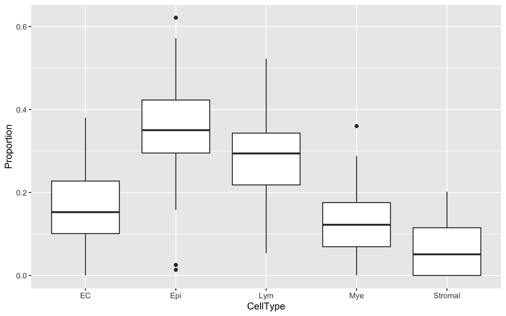

```r
estimated_cell_counts %>% pivot_longer(cols=c("EC", "Epi","Lym", "Mye", "Stromal"),
                                       names_to="CellType",
                                       values_to="Proportion") %>%
  ggplot(aes(x = CellType, y = Proportion)) +
  geom_boxplot()
```

# Conclusions

Thank you for using `NetworkDataCompanion`!

If you have any issues, please raise them as GitHub issues and/or contact the maintainer directly. This package is currently maintained by Kate Hoff Shutta (kshutta@hsph.harvard.edu).

# References

Du, Pan, Xiao Zhang, Chiang-Ching Huang, Nadereh Jafari, Warren A Kibbe, Lifang Hou, and Simon M Lin. 2010. “Comparison of Beta-Value and m-Value Methods for Quantifying Methylation Levels by Microarray Analysis.” *BMC Bioinformatics* 11: 1–9.

Fanfani, Viola, Katherine H Shutta, Panagiotis Mandros, Jonas Fischer, Enakshi Saha, Soel Micheletti, Chen Chen, Marouen Ben Guebila, Camila M Lopes-Ramos, and John Quackenbush. 2024. “Reproducible Processing of TCGA Regulatory Networks.” *bioRxiv*.

Teschendorff, Andrew E, Tianyu Zhu, Charles E Breeze, and Stephan Beck. 2020. “EPISCORE: Cell Type Deconvolution of Bulk Tissue DNA Methylomes from Single-Cell RNA-Seq Data.” *Genome Biology* 21: 1–33.